# 数学建模

### 模型知识点

### 排队论模型-泊松分布

**Wang Haihua**

🚅 🚋😜 🚑 🚔

# 泊松分布

## 二项分布和泊松分布

二项分布引入 如果一个牛仔一枪打中靶子的概率是$p$,如果我们让他开十枪，如果每次击中一次目标就能获得一分，问他一共能获得几分？

[figure not shown]

虽然我们不能在牛仔射击前准确地预测得出具体的分数$k$，但是可以求出$k$的概率分布，比如得九分的情况对应于：射失一发。根据组合数性质，它的概率是

$$ P(k=9) = C_{10}^{9}p^9(1-p) $$

同理，得$k$分的概率就是

$$ P(k) = C_{n}^{k}p^k(1-p)^{n-k} $$

对于一个神枪手（$p=1$）来说，他得十分的概率就是1.

二项分布和泊松分布的不同在于，前者研究的对象是$n$个离散的对象(10次射击)，而后者考察的是一段连续的时间。因为泊松分布就是在二项分布的基础上化离散为连续。

我们把单位时间划分为$n$个细小的时间片，假设在每个时间片内牛仔都在射击，击中的概率为$p$，只不过这次他发射的不是子弹，而是顾客。 “命中目标”就代表向服务台成功发射一名顾客，如果没有命中就表示顾客没能成功来到。单位时间内平均顾客的到达速度可以表示为

$$ \lambda = np $$

如果$n$不是无穷大，那么会出现某个时间片内出现两个顾客同时进入系统的情况，这样的话就和我们的假设【每个时间片内只能出现一个顾客或者不出现】不同了。所以$n$必须趋向无穷。 这也是为什么泊松分布的前提是$n$很大了（另一个前提是$p$很小）。

这样一来我们就能用二项分布的公式来表示单位时间内到来$k$个顾客的概率了。在单位时间，我们执行$n$次独立的“发射试验”，把顾客发射到系统的概率是$p$，那么单位时间到来$k$个顾客的概率就是

$$ P(k) = C_{n}^{k}p^k(1-p)^{n-k} $$

把这个组合数展开

$$ P(k)=\frac{n(n-1) \dots(n-k+1)}{k !} p^{k}(1-p)^{n-k} $$

上下同乘$(1-p)^{k}$

$$ P(k)=\frac{n(n-1) \ldots(n-k+1)}{k !} \frac{p^{k}(1-p)^{n}}{(1-p)^{k}} $$

把$p^k$拆成$k$个$p$连乘的形式放在左边分子上，

$$ P(k)=\frac{n p(n p-p) \ldots(n p-k p+p)}{k !} \frac{(1-p)^{n}}{(1-p)^{k}} $$

调整$(1-p)^n$,因为$p \to 0$ , 所以

$$ (1-p)^{-\frac{1}{p}} \rightarrow e $$$$ P(k)=\frac{n p(n p) \ldots(n p)}{k !} \frac{e^{-n p}}{(1)^{k}} $$

令$np=\lambda$,那么我们有

$$ P(k)=\frac{\lambda^{k}}{k !} e^{-\lambda} $$

这就是我们熟悉的泊松分布公式，其中$\lambda$的物理意义就是单位时间内顾客到达的数量，也就是平均到达率，是一个常数。

## 泊松分布案例

我们知道，在日常生活中，大量时间是有规律可循的，例如

- 某医院平均每小时出生3个婴儿
- 某公司平均每10分钟接到一个电话
- 某超市平均每天销售4包A品牌奶粉
- 某网站平均每分钟有2次访问

它们的特点就是，我们可以预估这些事件发生的总数，但是没法具体知道具体的发生时间。

比如我们提出这样的一问题：**已知医院平均每小时出生3个婴儿，请问下一个小时，会出生几个？**

有可能一下子出生6个，也要可能一个都没有。尽管我们不能做出明确的预测，但是从概率意义上，我们能够对他们的发生概率进行描述。

在本例中，到达速度$\lambda = 3$，我们来看下下个小时出生0个婴儿的概率

$$ P(0) = \frac{3^0}{0!}e^{-3} = 4.98\% $$

在接下来的一个小时中，至少出生两个婴儿的概率

$$ \begin{aligned}P(k\geq2) &=1-P(k=1)-P(k=0)\\& = 1- \frac{3^1}{1!}e^{-3} - \frac{3^0}{0!}e^{-3}\\& = 1 - 4e^{-3}\\&=80.09\%\end{aligned} $$

我们还可以看下泊松分布的图像。

```
<BarContainer object of 12 artists>
```

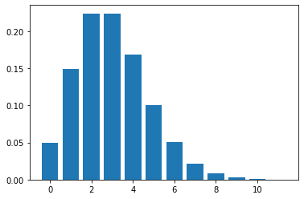

```python
import numpy as np
import matplotlib.pyplot as plt
%matplotlib inline
Lambda = 3
k = [i for i in range(12)]
pk = []
for kk in k:
    pk.append(Lambda ** kk / np.math.factorial(kk) * np.exp(-Lambda))
plt.bar(k,pk)
```

思考

- 泊松分布峰值表示的是什么意思？
- 在这个案例中，为什么会出现$n=2$和$n=3$两个最大概率？

## 指数分布

我们在排队论中，经常见到的另一个分布较指数分布。指数分布可以从泊松分布推导出来，我们来看下面的例子。

我们设$X$为前后两次婴儿出生的间隔时间，显然$X$也是随机变量。

以上次婴儿出生的时刻为0时刻，$[0,t]$时间段内不发生新出生的概率可以用泊松分布来衡量，这时候单位时间不再是1了，而是$t$，也就是$\lambda t = np$

$$ P(X>t) = P(k=0) = e^{-\lambda t} $$

反过来，在时间间隔$[0,t]$内发生事件的概率，就是1减去上面的值：

$$ P(X \leq t) = 1- e^{-\lambda t} $$

根据概率论知识，我们知道，分布函数是概率密度函数从负无穷到正无穷上的积分。对上述的分布函数进行求导，得到

$$ f(t) = \lambda e^{-\lambda t} $$

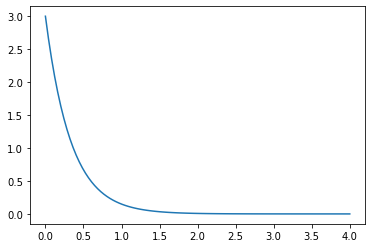

```python
import numpy as np
import matplotlib.pyplot as plt
%matplotlib inline
Lambda = 3
t = np.linspace(0,4,100)
pk = []
for tt in t:
    pk.append(Lambda*np.exp(-Lambda * tt))
plt.plot(t,pk)
```

## 关于泊松分布和指数分布的关系

在一个**满足马尔科夫过程**的排队系统中，随机变量$X$（单位时间内顾客到达数），满足泊松分布：$X \sim P(X)$，概率分布函数为

$$ P(x=k)=\frac{\lambda^{k}}{k !} e^{-\lambda} $$

注意：泊松分布中的$\lambda$，表征的是单位时间内平均到达的顾客数。

在一个**满足马尔科夫过程**的排队系统中，随机变量$T$（顾客相继到达时间间隔），满足负指数分布，

$$ T \sim f(t)=\lambda e^{-\lambda t} $$

注意：负指数分布中的$\lambda$，表征也的是单位时间内平均到达的顾客数。有时候，为了方便起见，我们常常做如下变换

$$ \mu = \frac{1}{\lambda} $$$$ T \sim f(t)=\frac{1}{\mu} e^{-\frac{1}{\mu} t} $$

我们可以这么理解：**泊松分布和负指数分布，是从两个角度，对同一个现象进行的描述。**

- 泊松分布关注的是单位时间内到达（或者离去）的顾客个数
- 负指数分布关注的是顾客到达（或者离去）的时间间隔

实际上，对于计算机模拟来说，后者更直观。我们来看一下程序实现。

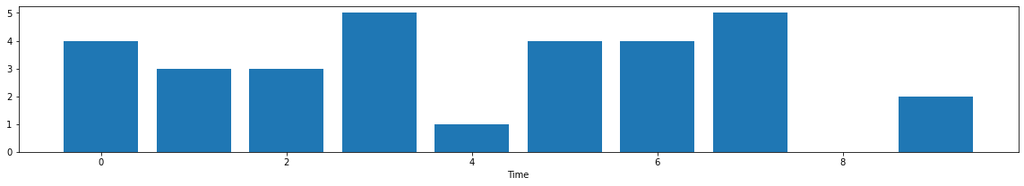

```python
import numpy as np
import matplotlib.pyplot as plt
%matplotlib inline
plt.figure(figsize=(20,3))
x1 = np.random.poisson(lam=3, size=10)
plt.bar(range(len(x1)),x1)
plt.xlabel('Time')
```

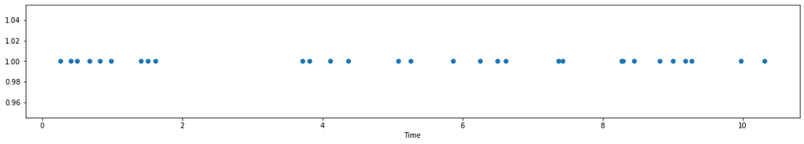

```python
import numpy as np
import matplotlib.pyplot as plt
%matplotlib inline

lambda1 = 3
size = 30
t1 = np.random.exponential(1/lambda1, size=size)

cumulativeTime = [t1[0]]
for time in t1[1:]:
    cumulativeTime.append(cumulativeTime[-1]+time)
plt.figure(figsize=(20,3))
plt.scatter(cumulativeTime,[1]*len(cumulativeTime))
plt.xlabel('Time')
```

**参考文献**

- ThomsonRen 的 github https://github.com/ThomsonRen/mathmodels